# Analiza czynników kształtujących wynagrodzenia w polskich powiatach

Oliwia Gruchała, Oliwia Jachym, Arkadiusz Kozak

# 1. Wprowadzenie danych

Celem badania jest zbudowanie modelu ekonometrycznego tłumaczącego kształtowanie się przeciętnego miesięcznego wynagrodzenia brutto w polskich powiatach. Dane zostały pobrane z bazy Głównego Urzędu Statystycznego (GUS). Do analizy wytypowano następujące zmienne: Zmienna objaśniana (Y): Przeciętne miesięczne wynagrodzenie brutto (w PLN).  
Zmienne objaśniające (X):

- X1: Dochody gmin per capita (PLN)
- X2: Stopa bezrobocia (%)
- X3: Ceny mieszkań (PLN/m2)
- X4: Liczba ludności na km2 (gęstość)
- X5: Wydatki na edukację per capita (PLN)
- X6: Liczba podmiotów gospodarczych (REGON) per capita

```r
library("dplyr")
```

```r
library("psych")
library("ggplot2")
library("lmtest")
library("sandwich")
library("patchwork")

# Wczytanie danych wszystkich zmiennych
dochody_gmin <- read.csv("dochody_gmin_X.csv", sep = ";", dec = ",")
gospodarka_podmiotowa <- read.csv("gospodarka_podmiotowa_X.csv", sep = ";", dec = ",")
bezrobocie <- read.csv("bezrobocie_X.csv", sep = ";", dec = ",")
mieszkania <- read.csv("mieszkania_X.csv", sep = ";", dec =",")
gestosc_ludnosci <- read.csv("gestosc_ludnosci_X.csv", sep = ";", dec = ",")
edukacja <- read.csv("wydatki_edu_X.csv", sep = ";", dec = ",")
ludnosc_ogolem <- read.csv("ludnosc_ogolem.csv", sep = ";", dec = ",")
wynagrodzenie <- read.csv("wynagrodzenie_Y.csv", sep = ";", dec = ",")

# Łączenie tabel po kodzie powiatu
data <- wynagrodzenie %>%
  left_join(dochody_gmin, by = "Kod") %>%
  left_join(gospodarka_podmiotowa, by = "Kod") %>%
  left_join(bezrobocie, by = "Kod") %>%
  left_join(mieszkania, by = "Kod") %>%
  left_join(gestosc_ludnosci, by = "Kod") %>%
  left_join(edukacja, by = "Kod") %>%
  left_join(ludnosc_ogolem, by = "Kod")

# Porządkowanie tabeli docelowej, usuwanie pozycji dublujących się na skutek łączenia danych
df <- data %>%
  select(
    kod = Kod,
    nazwa = Nazwa.x,
    wynagrodzenie = Wartosc.x,
    dochody = Wartosc.y,
    podmioty_REGON = Wartosc.x.x,
    bezrobocie = Wartosc.y.y,
    ceny_mieszkan = Wartosc.x.x.x,
    ludnosc = Wartosc.y.y.y,
    edukacja = Wartosc.x.x.x.x,
    ludzie_ogolem = Wartosc.y.y.y.y
  ) %>%
  mutate(
    edukacja_pc = edukacja / ludzie_ogolem,
    regon_pc = podmioty_REGON / ludzie_ogolem
  ) %>%
  select(-podmioty_REGON, -edukacja, -ludzie_ogolem)
```

### Pierwszy przegląd danych:

```r
describe(df[,3:9])
```

```
##               vars   n    mean      sd  median trimmed     mad     min      max
## wynagrodzenie    1 380 7600.53  813.76 7419.04 7478.43  459.92 6138.30 13672.98
## dochody          2 380 3895.55 1308.65 3577.26 3729.78  952.16 1901.07 11183.72
## bezrobocie       3 380    7.19    3.90    6.45    6.81    3.63    1.00    23.50
## ceny_mieszkan    4 380 5883.06 1929.59 5651.00 5668.29 1506.32 2728.00 19798.00
## ludnosc          5 380  341.41  603.88   88.05  183.56   62.49   17.90  3603.70
## edukacja_pc      6 380 3075.81  920.69 2825.83 2934.99  433.68  862.48 10476.72
## regon_pc         7 380    0.12    0.03    0.11    0.11    0.02    0.07     0.31
##                  range skew kurtosis    se
## wynagrodzenie  7534.68 2.87    13.87 41.75
## dochody        9282.65 1.80     5.46 67.13
## bezrobocie       22.50 0.93     0.69  0.20
## ceny_mieszkan 17070.00 2.41    11.37 98.99
## ludnosc        3585.80 2.58     6.67 30.98
## edukacja_pc    9614.24 2.89    14.97 47.23
## regon_pc          0.24 1.95     6.23  0.00
```

Nie występują braki danych, a wszystkie zmienne charakteryzuje skośność prawostronna (moda < mediana < średnia). Dodatkowo wartość kurtozy jest bardzo wysoka (leptokurtyczność), co wskazuje na występowanie wartości odstających.  
Jest to zjawisko typowe dla danych ekonomicznych, oznaczające, że większość powiatów charakteryzuje się wartościami niższymi lub przeciętnymi, podczas gdy nieliczne, bardzo rozwinięte ośrodki (wartości odstające) zawyżają średnią.

**W celu zmniejszenia skośności rozkładu danych zastosowano logarytmowanie.**

```r
df_ln <- df %>%
  mutate(
    wynagrodzenie = log(wynagrodzenie),
    dochody = log(dochody),
    bezrobocie = bezrobocie,
    ceny_mieszkan = log(ceny_mieszkan),
    ludnosc = log(ludnosc),
    edukacja_pc = log(edukacja_pc),
    regon_pc = log(regon_pc)
  )

describe(df_ln[,3:9])
```

```
##               vars   n  mean   sd median trimmed  mad   min   max range skew
## wynagrodzenie    1 380  8.93 0.10   8.91    8.92 0.06  8.72  9.52  0.80 2.01
## dochody          2 380  8.22 0.30   8.18    8.21 0.27  7.55  9.32  1.77 0.57
## bezrobocie       3 380  7.19 3.90   6.45    6.81 3.63  1.00 23.50 22.50 0.93
## ceny_mieszkan    4 380  8.64 0.29   8.64    8.63 0.26  7.91  9.89  1.98 0.54
## ludnosc          5 380  4.87 1.23   4.48    4.71 0.79  2.88  8.19  5.30 1.10
## edukacja_pc      6 380  8.00 0.25   7.95    7.98 0.16  6.76  9.26  2.50 0.62
## regon_pc         7 380 -2.16 0.24  -2.18   -2.18 0.22 -2.64 -1.17  1.46 0.87
##               kurtosis   se
## wynagrodzenie     7.14 0.00
## dochody           0.57 0.02
## bezrobocie        0.69 0.20
## ceny_mieszkan     1.46 0.01
## ludnosc           0.13 0.06
## edukacja_pc       4.50 0.01
## regon_pc          1.18 0.01
```

# 2. Analiza rozkładów zmiennych i ich zależności

Porównanie wykresów rozkładu wybranych zmiennych przed i po logarytmowaniu:

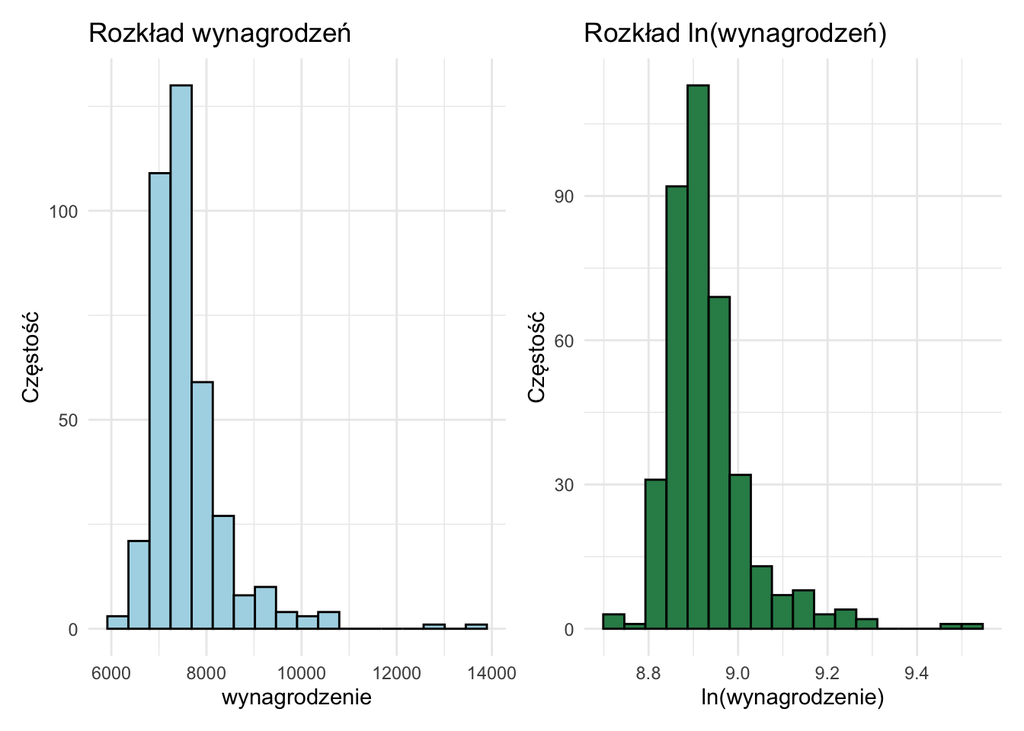

```r
p1 <- ggplot(df, aes(x = wynagrodzenie)) +
  geom_histogram(bins = 18, fill = "lightblue", color = "black") +
  labs(title = "Rozkład wynagrodzeń", x = "wynagrodzenie", y = "Częstość") +
  theme_minimal()

p2 <- ggplot(df_ln, aes(x = wynagrodzenie)) +
  geom_histogram(bins = 18, fill = "seagreen", color = "black") +
  labs(title = "Rozkład ln(wynagrodzeń)", x = "ln(wynagrodzenie)", y = "Częstość") +
  theme_minimal()

p1 + p2
```

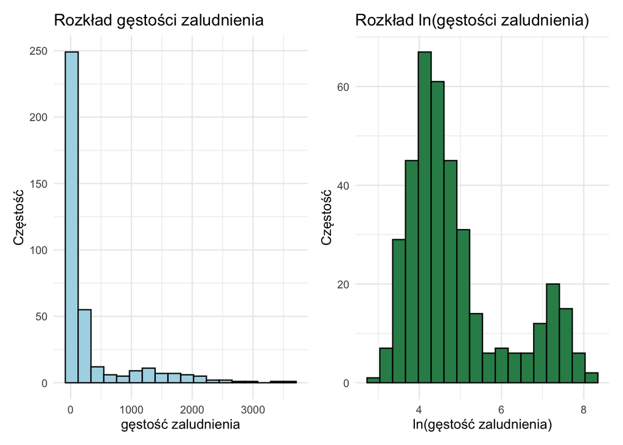

```r
p1 <- ggplot(df, aes(x = ludnosc)) +
  geom_histogram(bins = 18, fill = "lightblue", color = "black") +
  labs(title = "Rozkład gęstości zaludnienia", x = "gęstość zaludnienia", y = "Częstość") +
  theme_minimal()

p2 <- ggplot(df_ln, aes(x = ludnosc)) +
  geom_histogram(bins = 18, fill = "seagreen", color = "black") +
  labs(title = "Rozkład ln(gęstości zaludnienia)", x = "ln(gęstość zaludnienia)", y = "Częstość") +
  theme_minimal()

p1 + p2
```

Przedstawienie danych w postaci wykresów pudełkowych w celu identyfikacji wartości odstających.

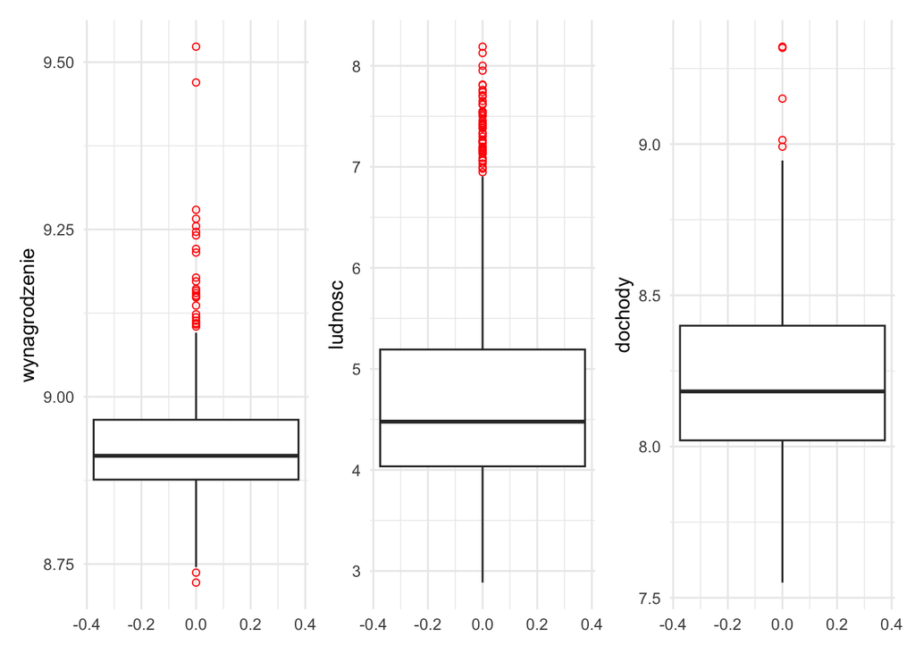

```r
p1 <- ggplot(df_ln, aes(y = wynagrodzenie)) +
  geom_boxplot(outlier.colour = "red", outlier.shape = 1) +
  theme_minimal()

p2 <- ggplot(df_ln, aes(y = ludnosc)) +
  geom_boxplot(outlier.colour = "red", outlier.shape = 1) +
  theme_minimal()

p3 <- ggplot(df_ln, aes(y = dochody)) +
  geom_boxplot(outlier.colour = "red", outlier.shape = 1) +
  theme_minimal()

p1 + p2 + p3
```

Jak widać wśród danych występują liczne wartości odstające. **W celu usunięcia outlinerów zaburzających estymację zastosowano metodę opartą na rozstępie międzykwartylowym (IQR).**

```r
usun_outliery <- function(dane) {
  dane_czyste <- dane
  kolumny <- c("wynagrodzenie", "dochody", "bezrobocie", "ceny_mieszkan",
               "ludnosc", "edukacja_pc", "regon_pc")

  for (kol in kolumny) {
    Q1 <- quantile(dane_czyste[[kol]], 0.25, na.rm = TRUE)
    Q3 <- quantile(dane_czyste[[kol]], 0.75, na.rm = TRUE)
    IQR <- Q3 - Q1

    dolna_granica <- Q1 - 3 * IQR
    gorna_granica <- Q3 + 3 * IQR

    dane_czyste <- dane_czyste %>%
      filter(get(kol) >= dolna_granica & get(kol) <= gorna_granica)
  }
  return(dane_czyste)
}

df_czyste <- usun_outliery(df_ln)
print(paste("Liczba obserwacji przed czyszczeniem:", nrow(df_ln)))
```

```
## [1] "Liczba obserwacji przed czyszczeniem: 380"
```

```r
print(paste("Liczba obserwacji po usunięciu outlierów:", nrow(df_czyste)))
```

```
## [1] "Liczba obserwacji po usunięciu outlierów: 363"
```

Dane nieznajdujące się w przedziale [Q1 - 3IRQ, Q3 + 3IRQ] zostały usunięte i nie będą brane pod uwagę w dalszej analizie. Liczba usuniętych obserwacji odstających wynosi **17**.

# 3. Podział na zbiór treningowy i testowy

Zbiór danych został losowo podzielony na zbiór treningowy (80% obserwacji) oraz zbiór testowy (20% obserwacji).

```r
set.seed(2024)

indeksy_treningowe <- sample(1:nrow(df_czyste), 0.8 * nrow(df_czyste))

df_train <- df_czyste[indeksy_treningowe, ]
df_test  <- df_czyste[-indeksy_treningowe, ]
```

# 4. Dobór zmiennych i estymacja modelu

Do wyłonienia ostatecznej postaci modelu zastosowano metodę eliminacji wstecznej na zbiorze treningowym. Estymację rozpoczęto od pełnego modelu ze wszystkimi sześcioma zmiennymi objaśniającymi. Następnie, w kolejnych krokach, usuwano po jednej zmiennej wykazującej najwyższą wartość p-value, stale kontrolując wartość skorygowanego współczynnika determinacji (R^2).

#### Model 1

```r
model_1 <- lm(wynagrodzenie ~ dochody + bezrobocie + ceny_mieszkan +
                ludnosc + edukacja_pc + regon_pc, data = df_train)
summary(model_1)
```

```
##
## Call:
## lm(formula = wynagrodzenie ~ dochody + bezrobocie + ceny_mieszkan +
##     ludnosc + edukacja_pc + regon_pc, data = df_train)
##
## Residuals:
##       Min        1Q    Median        3Q       Max
## -0.222471 -0.033814 -0.004249  0.031399  0.233802
##
## Coefficients:
##                Estimate Std. Error t value Pr(>|t|)
## (Intercept)    7.469302   0.311741  23.960  < 2e-16 ***
## dochody        0.152316   0.020620   7.387 1.69e-12 ***
## bezrobocie     0.001652   0.001116   1.480  0.13994
## ceny_mieszkan  0.053059   0.016229   3.269  0.00121 **
## ludnosc        0.012598   0.004688   2.687  0.00763 **
## edukacja_pc   -0.043602   0.026396  -1.652  0.09968 .
## regon_pc      -0.009844   0.024242  -0.406  0.68500
## ---
## Signif. codes:  0 '***' 0.001 '**' 0.01 '*' 0.05 '.' 0.1 ' ' 1
##
## Residual standard error: 0.05864 on 283 degrees of freedom
## Multiple R-squared:  0.4338, Adjusted R-squared:  0.4218
## F-statistic: 36.14 on 6 and 283 DF,  p-value: < 2.2e-16
```

Uzyskane wyniki świadczą o tym, że zmienna Y została wyjaśniona w 43,38% (R^2). Najistotniejszą zmienną w modelu jest dochód, następnie cena mieszkań za m2 oraz gęstość zaludnienia. Zmienne nieistotne statystycznie to: wskaźnik bezrobocia oraz liczba podmiotów gospodarczych.

#### Model 2 - eliminacja zmiennej regon_pc (najwyższe p_value)

```r
model_2 <- lm(wynagrodzenie ~ dochody + bezrobocie + ceny_mieszkan +
                ludnosc + edukacja_pc, data = df_train)

summary(model_2)
```

```
##
## Call:
## lm(formula = wynagrodzenie ~ dochody + bezrobocie + ceny_mieszkan +
##     ludnosc + edukacja_pc, data = df_train)
##
## Residuals:
##       Min        1Q    Median        3Q       Max
## -0.222230 -0.034449 -0.005142  0.031874  0.237402
##
## Coefficients:
##                Estimate Std. Error t value Pr(>|t|)
## (Intercept)    7.545528   0.248521  30.362  < 2e-16 ***
## dochody        0.147517   0.016872   8.743  < 2e-16 ***
## bezrobocie     0.001648   0.001114   1.479 0.140292
## ceny_mieszkan  0.050615   0.015050   3.363 0.000876 ***
## ludnosc        0.012481   0.004672   2.672 0.007986 **
## edukacja_pc   -0.042832   0.026289  -1.629 0.104361
## ---
## Signif. codes:  0 '***' 0.001 '**' 0.01 '*' 0.05 '.' 0.1 ' ' 1
##
## Residual standard error: 0.05855 on 284 degrees of freedom
## Multiple R-squared:  0.4335, Adjusted R-squared:  0.4235
## F-statistic: 43.47 on 5 and 284 DF,  p-value: < 2.2e-16
```

Usunięcie zmiennej regon spowodowało niewielki wzrost skorygowanego R^2: z 0,4218 wsrósł do 0,4235, a zatem poprawę modelu.

#### Model 3 - eliminacja zmiennej bezrobocie (najwyższe p_value)

```r
model_3 <- lm(wynagrodzenie ~ dochody + ceny_mieszkan +
                ludnosc + edukacja_pc, data = df_train)

summary(model_3)
```

```
##
## Call:
## lm(formula = wynagrodzenie ~ dochody + ceny_mieszkan + ludnosc +
##     edukacja_pc, data = df_train)
##
## Residuals:
##       Min        1Q    Median        3Q       Max
## -0.227956 -0.034760 -0.002601  0.032234  0.242438
##
## Coefficients:
##               Estimate Std. Error t value Pr(>|t|)
## (Intercept)    7.70634    0.22393  34.414  < 2e-16 ***
## dochody        0.13884    0.01585   8.758  < 2e-16 ***
## ceny_mieszkan  0.04501    0.01460   3.084  0.00224 **
## ludnosc        0.01228    0.00468   2.624  0.00916 **
## edukacja_pc   -0.04638    0.02623  -1.768  0.07815 .
## ---
## Signif. codes:  0 '***' 0.001 '**' 0.01 '*' 0.05 '.' 0.1 ' ' 1
##
## Residual standard error: 0.05867 on 285 degrees of freedom
## Multiple R-squared:  0.4291, Adjusted R-squared:  0.4211
## F-statistic: 53.56 on 4 and 285 DF,  p-value: < 2.2e-16
```

Mimo iż zmienna nie jest istotna statystycznie to jej usunięcie spowodowało obniżenie skorygowangego R^2 z 0,4235 do 0,4211, a tym samym pogorszyło jakość modelu. W związku z tym **nie należy usuwać** jej z modelu.  
**Jedyną zmienną, która nie zostanie uwzględniona w modelu jest regon_pc, czyli liczba podmiotów gospodarczych per capita.**

```r
model_ostateczny <- lm(wynagrodzenie ~ dochody + bezrobocie + ceny_mieszkan +
                ludnosc + edukacja_pc, data = df_train)
```

# 5. Diagnostyka

#### Test Shapiro-Wilka na normalność reszt

```r
# H0: reszty mają rozkład normalny
shapiro.test(residuals(model_ostateczny))
```

```
##
##  Shapiro-Wilk normality test
##
## data:  residuals(model_ostateczny)
## W = 0.96454, p-value = 1.515e-06
```

Wartość p-value wynosi:1.515e-06, zatem należy odrzucić hipotezę główną o normalności rozkładu reszt.

#### Test Breuscha Pagana na występowanie zjawiska homoskedastyczności

```r
# H0: Występuje homoskedastyczność składnika losowego.
bptest(model_ostateczny)
```

```
##
##  studentized Breusch-Pagan test
##
## data:  model_ostateczny
## BP = 27.178, df = 5, p-value = 5.266e-05
```

Wartość p-value wynosi:5.266e-05, zatem należy odrzucić hipotezę główną o homoskedastyczności. Oznacza to, że występuje heteroskedastyczność, czyli nierówność wariancji składnika losowego.

# 6. Poprawa modelu

W celu poprawy modelu i ograniczenia wpływu heteroskedastyczności na wyniki estymacj zastosowano **odporne błędy standardowe**.

```r
model_odporny <-coeftest(model_ostateczny, vcovHC(model_ostateczny))
print(model_odporny)
```

```
##
## t test of coefficients:
##
##                 Estimate Std. Error t value  Pr(>|t|)
## (Intercept)    7.5455280  0.3510980 21.4912 < 2.2e-16 ***
## dochody        0.1475166  0.0220628  6.6862 1.212e-10 ***
## bezrobocie     0.0016476  0.0012630  1.3045   0.19310
## ceny_mieszkan  0.0506155  0.0201475  2.5122   0.01255 *
## ludnosc        0.0124810  0.0055983  2.2294   0.02657 *
## edukacja_pc   -0.0428323  0.0345765 -1.2388   0.21645
## ---
## Signif. codes:  0 '***' 0.001 '**' 0.01 '*' 0.05 '.' 0.1 ' ' 1
```

Mimo, że test Shapiro-Wilka wykazał brak normalności reszt, nie wprowadzono dalszych zmian w modelu. Przy dużej liczbie badanych powiatów (290 w zbiorze treningowym) błędy te nie wpływają negatywnie na wiarygodność wyników.

# 7. Predykcja na zbiór testowy i analiza błędów ex post

```r
prognozy_ln <- predict(model_ostateczny, newdata = df_test)

# Porównanie prognozy z rzeczywistością (przywrócenie wartości zlogarytmowanych na PLN)
rzeczywiste_place <- exp(df_test$wynagrodzenie)
przewidziane_place <- exp(prognozy_ln)
bledy <- rzeczywiste_place - przewidziane_place

mae <- mean(abs(bledy))
rmse <- sqrt(mean(bledy^2))
mape <- mean(abs(bledy / rzeczywiste_place)) * 100

cat("Statystyki błędów na zbiorze testowym:\n",
    "MAE: ", round(mae, 2), " PLN\n",
    "RMSE: ", round(rmse, 2), " PLN\n",
    "MAPE: ", round(mape, 2), " %")
```

```
## Statystyki błędów na zbiorze testowym:
##  MAE:  350.17  PLN
##  RMSE:  429.37  PLN
##  MAPE:  4.68  %
```

Uzyskane wyniki predykcji świadczą o wysokiej jakości zbudowanego modelu. Relatywnie niewielka różnica między RMSE a MAE wskazuje na stabilność modelu. Średnio prognozowane wyniki różnią się o **350,17 zł** od płac rzeczywistych. Błąd procentowy MAPE na poziomie **4,68%** potwierdza, że model bardzo precyzyjnie wyjaśnia zróżnicowanie wynagrodzeń w polskich powiatach, mimo wcześniejszych problemów z normalnością reszt.

# 8. Podsumowanie

#### Ostateczne równanie:

**ln(wynagrodzenie) = 7,5455 + 0,1475⋅ln(dochody) + 0,0016⋅bezrobocie + 0,0506⋅ln(ceny_mieszkan) + 0,0125⋅ln(ludnosc) - 0,0428⋅ln(edukacja_pc)**